# SOC/CSSS/CSDE 533 Homework 1 Solutions

Sarah Kilpatrick

2025-01-22

# Problem 1: Estimating the growth rate of a closed population - 10 points

*Essential Demographic Methods* *Ch. 1 Exercise 11. Dates at which world population first exceeded each number of billions from 1 to 7 are estimated to be 1) 1800, 2) 1925, 3) 1960, 4) 1974, 5) 1987, 6) 1999, 7) 2011. Estimate the **growth rate**,* $\mathbf{R}$ *between each of these dates. Present your results in a table.*

We know from chapter 1 that the initial formula for exponential growth can be written as $K(t + n) = {K(t)\cdot{e^{R_{n}}}}$ where:

- $t$: year of step 1

- $n$: number of years after step 1

- $K(t)$: Population at year t

- $K(t+n)$: Population at year t+n

- $R_{n}$: exponential growth rate for years n

Therefore, we solve for $e^{R_{n}}$ by dividing $K(t)$ from both sides and taking the natural log of both sides: $ln({\frac{K(t + n)}{K(t)}}) = R_{n}$

```r
# creates the data frame
years <- c(1800, 1925, 1960, 1974, 1987, 1999, 2011)
population_B <- c(1, 2, 3, 4, 5, 6, 7)
# population in billions
population_data <- data.frame(years, population_B)
# print(population_data)

population_data <- population_data %>%
    mutate(growth_rate = log(population_B/lag(population_B))/(years - lag(years)))

# View the result in a pretty way
kable(population_data, col.names = c("Year", "Population (Billion)", "Growth Rate"),
    digits = 4, caption = "Population and Growth Rate Over Time") %>%
    kable_styling(font_size = 15)
```

Population and Growth Rate Over Time

| Year | Population (Billion) | Growth Rate |
| --- | --- | --- |
| 1800 | 1 | NA |
| 1925 | 2 | 0.0055 |
| 1960 | 3 | 0.0116 |
| 1974 | 4 | 0.0205 |
| 1987 | 5 | 0.0172 |
| 1999 | 6 | 0.0152 |
| 2011 | 7 | 0.0128 |

The code containing mutate() and piping is adapted from the Posit Community Forum about the tidyverse and dplyr packages.

# Problem 2: Estimating the growth rate of a closed population - 40 points

**(a)** **10 points** *Use the `pop1dt` or `pop1` datasets to estimate the yearly growth rates,* $R_t$*, under the assumption of **exponential growth**, for the world between 1951-2023. Show your calculation code in an `R` chunk. In a two-panel plot, plot the world’s population each year along side a plot of the yearly growth rates.*

The code to load the data is adapted from the [UNWPP2024 R Package Github](https://github.com/PPgp/wpp2024)

```r
# Filters the data for World population and years between [1951,2023]
pop1dt_world_5123 <- pop1dt %>%
    filter(country_code == 900, year >= 1951, year <= 2023) %>%
    select(year, pop) %>%
    arrange(year)

# Print the filtered dataset head(pop1dt_world_5123)
```

The code to filter, select, and arrange is adapted from the tplyr and tidyverse article called [Keep Rows That Match a Condition](https://dplyr.tidyverse.org/reference/filter.html).

This code calculates the exponential growth rate, but does not convert it to a percent.

```r
# Calculates growth rates
pop1dt_world_5123 <- pop1dt_world_5123 %>%
    mutate(growth_rate = log((pop/lag(pop))/(year - lag(year))))  # Exponential growth rate

kable(pop1dt_world_5123 %>%
    mutate(pop = comma(pop)), col.names = c("Year", "Population", "Growth Rate"),
    digits = 4, caption = "World Population and Growth Rate Over Time (1951-2023)") %>%
    kable_styling(font_size = 15) %>%
    scroll_box(width = "600px", height = "500px")
```

World Population and Growth Rate Over Time (1951-2023)

| Year | Population | Growth Rate |
| --- | --- | --- |
| 1951 | 2,559,092 | NA |
| 1952 | 2,609,080 | 0.0193 |
| 1953 | 2,659,132 | 0.0190 |
| 1954 | 2,712,658 | 0.0199 |
| 1955 | 2,767,770 | 0.0201 |
| 1956 | 2,823,050 | 0.0198 |
| 1957 | 2,882,187 | 0.0207 |
| 1958 | 2,940,313 | 0.0200 |
| 1959 | 2,991,588 | 0.0173 |
| 1960 | 3,039,354 | 0.0158 |
| 1961 | 3,090,386 | 0.0167 |
| 1962 | 3,156,363 | 0.0211 |
| 1963 | 3,229,253 | 0.0228 |
| 1964 | 3,299,722 | 0.0216 |
| 1965 | 3,369,345 | 0.0209 |
| 1966 | 3,438,737 | 0.0204 |
| 1967 | 3,508,089 | 0.0200 |
| 1968 | 3,582,286 | 0.0209 |
| 1969 | 3,656,698 | 0.0206 |
| 1970 | 3,732,670 | 0.0206 |
| 1971 | 3,807,026 | 0.0197 |
| 1972 | 3,882,810 | 0.0197 |
| 1973 | 3,958,800 | 0.0194 |
| 1974 | 4,034,032 | 0.0188 |
| 1975 | 4,107,439 | 0.0180 |
| 1976 | 4,181,054 | 0.0178 |
| 1977 | 4,254,674 | 0.0175 |
| 1978 | 4,329,521 | 0.0174 |
| 1979 | 4,407,558 | 0.0179 |
| 1980 | 4,487,655 | 0.0180 |
| 1981 | 4,569,900 | 0.0182 |
| 1982 | 4,655,447 | 0.0185 |
| 1983 | 4,739,208 | 0.0178 |
| 1984 | 4,825,143 | 0.0180 |
| 1985 | 4,912,744 | 0.0180 |
| 1986 | 5,003,402 | 0.0183 |
| 1987 | 5,096,091 | 0.0184 |
| 1988 | 5,187,894 | 0.0179 |
| 1989 | 5,280,970 | 0.0178 |
| 1990 | 5,374,637 | 0.0176 |
| 1991 | 5,462,835 | 0.0163 |
| 1992 | 5,549,145 | 0.0157 |
| 1993 | 5,633,945 | 0.0152 |
| 1994 | 5,717,157 | 0.0147 |
| 1995 | 5,800,600 | 0.0145 |
| 1996 | 5,883,511 | 0.0142 |
| 1997 | 5,966,065 | 0.0139 |
| 1998 | 6,048,069 | 0.0137 |
| 1999 | 6,129,944 | 0.0134 |
| 2000 | 6,213,462 | 0.0135 |
| 2001 | 6,296,411 | 0.0133 |
| 2002 | 6,379,050 | 0.0130 |
| 2003 | 6,461,673 | 0.0129 |
| 2004 | 6,545,082 | 0.0128 |
| 2005 | 6,628,858 | 0.0127 |
| 2006 | 6,714,046 | 0.0128 |
| 2007 | 6,800,572 | 0.0128 |
| 2008 | 6,888,344 | 0.0128 |
| 2009 | 6,977,189 | 0.0128 |
| 2010 | 7,066,275 | 0.0127 |
| 2011 | 7,155,572 | 0.0126 |
| 2012 | 7,246,832 | 0.0127 |
| 2013 | 7,336,755 | 0.0123 |
| 2014 | 7,426,478 | 0.0122 |
| 2015 | 7,514,506 | 0.0118 |
| 2016 | 7,602,603 | 0.0117 |
| 2017 | 7,688,633 | 0.0113 |
| 2018 | 7,771,173 | 0.0107 |
| 2019 | 7,851,415 | 0.0103 |
| 2020 | 7,922,588 | 0.0090 |
| 2021 | 7,986,309 | 0.0080 |
| 2022 | 8,056,506 | 0.0088 |
| 2023 | 8,126,964 | 0.0087 |

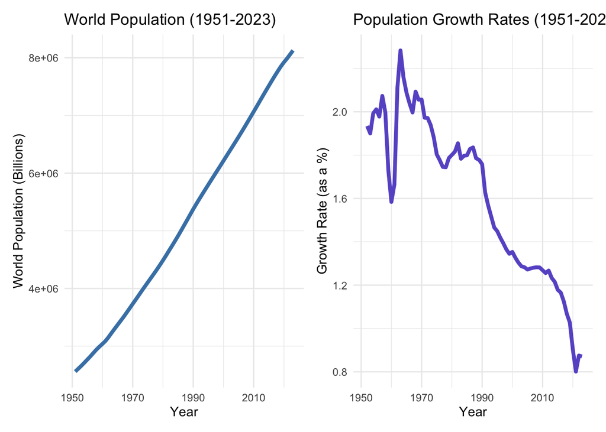

```r
# world pop
plot1 = ggplot(pop1dt_world_5123) + geom_line(aes(x = year, y = pop), color = "steelblue",
    linewidth = 1.5) + labs(title = "World Population (1951-2023)", x = "Year", y = "World Population (Billions)") +
    theme_minimal()
# pop growth rates
plot2 = ggplot(pop1dt_world_5123) + geom_line(aes(x = year, y = growth_rate * 100),
    color = "slateblue", linewidth = 1.5) + labs(title = "Population Growth Rates (1951-2023)",
    x = "Year", y = "Growth Rate (as a %)") + theme_minimal()

# two panel plot
plot1 + plot2 + plot_layout(ncol = 2)
```

**(b)** **10 points** *Use the `misc1dt` dataset’s births and deaths in combination with the `pop1dt` or `pop1` datasets to calculate the person-years lived and the yearly global crude growth rate,* $CGR_t$ *for* $t = 1951$ *and* $t = 2023$*. Show your calculation code in an `R` chunk and present your answers in a table. State any assumptions you make while calculating your estimate of person-years.*

**Person-years example:** 5 babies, four live to age of 5 but one lives to 6 months, the person-years for these 5 babies total are 5 + 5 + 5 + 5 + 0.5 = 20.5 person-years.

It appears that $\text{Crude Growth Rate (CGR)} = \text{Crude Birth Rate (CBR)} - \text{Crude Death Rate (CDR)}$. This comes from the textbook Essential Demographic Methods by Wachter and the [Periods and Cohorts lecture by Ernesto F.L. Amaral, 2019](https://www.ernestoamaral.com/docs/soci320-19fall/Lecture02.pdf).

This code chunk calculates the Crude Growth Rate (CGR) in a new column labeled cgr.

```r
# Filters the data for World population and years between [1951,2023]
misc1dt_world_cgr_5123 <- misc1dt %>%
    filter(country_code == 900, year >= 1951, year <= 2023) %>%
    select(year, cbr, cdr) %>%
    arrange(year) %>%
    mutate(cgr = cbr - cdr)

# present the filtered dataset
kable(misc1dt_world_cgr_5123, col.names = c("Year", "Crude Birth Rate", "Crude Death Rate",
    "Crude Growth Rate"), digits = 2, caption = "Yearly Crude Growth Rates for `misc1dt` dataset (1951-2023)") %>%
    kable_styling(font_size = 15) %>%
    scroll_box(width = "900px", height = "500px")
```

Yearly Crude Growth Rates for `misc1dt` dataset (1951-2023)

| Year | Crude Birth Rate | Crude Death Rate | Crude Growth Rate |
| --- | --- | --- | --- |
| 1951 | 36.46 | 18.99 | 17.47 |
| 1952 | 37.68 | 18.34 | 19.34 |
| 1953 | 36.94 | 17.93 | 19.00 |
| 1954 | 37.30 | 17.37 | 19.93 |
| 1955 | 37.13 | 17.02 | 20.11 |
| 1956 | 36.40 | 16.63 | 19.78 |
| 1957 | 37.16 | 16.43 | 20.73 |
| 1958 | 35.94 | 15.98 | 19.97 |
| 1959 | 34.39 | 17.10 | 17.29 |
| 1960 | 33.95 | 18.11 | 15.84 |
| 1961 | 32.94 | 16.29 | 16.65 |
| 1962 | 35.87 | 14.75 | 21.12 |
| 1963 | 37.52 | 14.69 | 22.83 |
| 1964 | 35.93 | 14.34 | 21.59 |
| 1965 | 35.34 | 14.46 | 20.88 |
| 1966 | 34.44 | 14.05 | 20.38 |
| 1967 | 33.66 | 13.70 | 19.97 |
| 1968 | 34.36 | 13.44 | 20.93 |
| 1969 | 33.77 | 13.21 | 20.56 |
| 1970 | 33.60 | 13.04 | 20.56 |
| 1971 | 32.82 | 13.10 | 19.72 |
| 1972 | 32.13 | 12.42 | 19.71 |
| 1973 | 31.52 | 12.13 | 19.38 |
| 1974 | 30.70 | 11.88 | 18.82 |
| 1975 | 29.73 | 11.70 | 18.03 |
| 1976 | 29.27 | 11.51 | 17.76 |
| 1977 | 28.64 | 11.18 | 17.45 |
| 1978 | 28.46 | 11.02 | 17.44 |
| 1979 | 28.61 | 10.75 | 17.86 |
| 1980 | 28.66 | 10.65 | 18.01 |
| 1981 | 28.64 | 10.48 | 18.16 |
| 1982 | 28.88 | 10.33 | 18.55 |
| 1983 | 28.09 | 10.26 | 17.83 |
| 1984 | 28.10 | 10.13 | 17.97 |
| 1985 | 28.01 | 10.02 | 17.99 |
| 1986 | 28.10 | 9.81 | 18.28 |
| 1987 | 27.99 | 9.64 | 18.36 |
| 1988 | 27.42 | 9.56 | 17.85 |
| 1989 | 27.18 | 9.39 | 17.78 |
| 1990 | 26.93 | 9.35 | 17.58 |
| 1991 | 25.52 | 9.25 | 16.28 |
| 1992 | 24.81 | 9.13 | 15.68 |
| 1993 | 24.26 | 9.09 | 15.17 |
| 1994 | 23.81 | 9.15 | 14.66 |
| 1995 | 23.42 | 8.93 | 14.49 |
| 1996 | 22.99 | 8.80 | 14.19 |
| 1997 | 22.61 | 8.68 | 13.93 |
| 1998 | 22.28 | 8.63 | 13.65 |
| 1999 | 22.02 | 8.57 | 13.45 |
| 2000 | 22.00 | 8.46 | 13.53 |
| 2001 | 21.64 | 8.38 | 13.26 |
| 2002 | 21.36 | 8.32 | 13.04 |
| 2003 | 21.14 | 8.27 | 12.87 |
| 2004 | 21.00 | 8.18 | 12.83 |
| 2005 | 20.82 | 8.11 | 12.72 |
| 2006 | 20.75 | 7.99 | 12.77 |
| 2007 | 20.71 | 7.90 | 12.80 |
| 2008 | 20.71 | 7.89 | 12.82 |
| 2009 | 20.62 | 7.81 | 12.81 |
| 2010 | 20.42 | 7.73 | 12.69 |
| 2011 | 20.23 | 7.68 | 12.56 |
| 2012 | 20.28 | 7.61 | 12.67 |
| 2013 | 19.89 | 7.56 | 12.33 |
| 2014 | 19.68 | 7.53 | 12.15 |
| 2015 | 19.32 | 7.54 | 11.78 |
| 2016 | 19.16 | 7.51 | 11.66 |
| 2017 | 18.78 | 7.53 | 11.25 |
| 2018 | 18.16 | 7.48 | 10.68 |
| 2019 | 17.74 | 7.47 | 10.27 |
| 2020 | 17.08 | 8.06 | 9.02 |
| 2021 | 16.78 | 8.77 | 8.01 |
| 2022 | 16.52 | 7.76 | 8.75 |
| 2023 | 16.33 | 7.62 | 8.71 |

There are many ways to calculate annual person-years, and I will be using the method presented in Amaral’s slide 14 under the title Approximation for PPYL.

```r
# Merge the two datasets so there's just 1 with Year, Population,
# prev-calculated Growth Rate, cbr, cdr, and cgr.
pop1_misc1dt_world_cgr_5123 = merge(pop1dt_world_5123, misc1dt_world_cgr_5123, by = "year")

# head(pop1_misc1dt_world_cgr_5123)
```

```r
# Creates a new column called pop_eoy, the population at the end of the year,
# which is = pop*e^(growth rate)
pop1_misc1dt_world_cgr_5123$pop_eoy <- pop1_misc1dt_world_cgr_5123$pop * exp(pop1_misc1dt_world_cgr_5123$growth_rate)

# Calculate person-years as the average of start pop and end pop_eoy
pop1_misc1dt_world_cgr_5123$personyears <- (pop1_misc1dt_world_cgr_5123$pop + pop1_misc1dt_world_cgr_5123$pop_eoy)/2

# show final answer w Kable
kable(pop1_misc1dt_world_cgr_5123 %>%
    mutate(pop = comma(pop), pop_eoy = comma(pop_eoy), personyears = comma(personyears)),
    col.names = c("Year", "Population", "Growth Rate", "Crude Birth Rate", "Crude Death Rate",
        "Crude Growth Rate", "Population End-Of-Year", "Person-Years"), digits = 2,
    caption = "Yearly Person-years calculation (1951-2023)") %>%
    kable_styling(font_size = 15) %>%
    scroll_box(width = "900px", height = "500px")
```

Yearly Person-years calculation (1951-2023)

| Year | Population | Growth Rate | Crude Birth Rate | Crude Death Rate | Crude Growth Rate | Population End-Of-Year | Person-Years |
| --- | --- | --- | --- | --- | --- | --- | --- |
| 1951 | 2,559,092 | NA | 36.46 | 18.99 | 17.47 | NA | NA |
| 1952 | 2,609,080 | 0.02 | 37.68 | 18.34 | 19.34 | 2,660,045 | 2,634,562 |
| 1953 | 2,659,132 | 0.02 | 36.94 | 17.93 | 19.00 | 2,710,144 | 2,684,638 |
| 1954 | 2,712,658 | 0.02 | 37.30 | 17.37 | 19.93 | 2,767,260 | 2,739,959 |
| 1955 | 2,767,770 | 0.02 | 37.13 | 17.02 | 20.11 | 2,824,002 | 2,795,886 |
| 1956 | 2,823,050 | 0.02 | 36.40 | 16.63 | 19.78 | 2,879,434 | 2,851,242 |
| 1957 | 2,882,187 | 0.02 | 37.16 | 16.43 | 20.73 | 2,942,562 | 2,912,374 |
| 1958 | 2,940,313 | 0.02 | 35.94 | 15.98 | 19.97 | 2,999,611 | 2,969,962 |
| 1959 | 2,991,588 | 0.02 | 34.39 | 17.10 | 17.29 | 3,043,758 | 3,017,673 |
| 1960 | 3,039,354 | 0.02 | 33.95 | 18.11 | 15.84 | 3,087,882 | 3,063,618 |
| 1961 | 3,090,386 | 0.02 | 32.94 | 16.29 | 16.65 | 3,142,274 | 3,116,330 |
| 1962 | 3,156,363 | 0.02 | 35.87 | 14.75 | 21.12 | 3,223,749 | 3,190,056 |
| 1963 | 3,229,253 | 0.02 | 37.52 | 14.69 | 22.83 | 3,303,826 | 3,266,539 |
| 1964 | 3,299,722 | 0.02 | 35.93 | 14.34 | 21.59 | 3,371,729 | 3,335,726 |
| 1965 | 3,369,345 | 0.02 | 35.34 | 14.46 | 20.88 | 3,440,438 | 3,404,892 |
| 1966 | 3,438,737 | 0.02 | 34.44 | 14.05 | 20.38 | 3,509,557 | 3,474,147 |
| 1967 | 3,508,089 | 0.02 | 33.66 | 13.70 | 19.97 | 3,578,840 | 3,543,464 |
| 1968 | 3,582,286 | 0.02 | 34.36 | 13.44 | 20.93 | 3,658,052 | 3,620,169 |
| 1969 | 3,656,698 | 0.02 | 33.77 | 13.21 | 20.56 | 3,732,655 | 3,694,676 |
| 1970 | 3,732,670 | 0.02 | 33.60 | 13.04 | 20.56 | 3,810,221 | 3,771,445 |
| 1971 | 3,807,026 | 0.02 | 32.82 | 13.10 | 19.72 | 3,882,863 | 3,844,944 |
| 1972 | 3,882,810 | 0.02 | 32.13 | 12.42 | 19.71 | 3,960,102 | 3,921,456 |
| 1973 | 3,958,800 | 0.02 | 31.52 | 12.13 | 19.38 | 4,036,278 | 3,997,539 |
| 1974 | 4,034,032 | 0.02 | 30.70 | 11.88 | 18.82 | 4,110,693 | 4,072,362 |
| 1975 | 4,107,439 | 0.02 | 29.73 | 11.70 | 18.03 | 4,182,182 | 4,144,810 |
| 1976 | 4,181,054 | 0.02 | 29.27 | 11.51 | 17.76 | 4,255,988 | 4,218,521 |
| 1977 | 4,254,674 | 0.02 | 28.64 | 11.18 | 17.45 | 4,329,590 | 4,292,132 |
| 1978 | 4,329,521 | 0.02 | 28.46 | 11.02 | 17.44 | 4,405,686 | 4,367,604 |
| 1979 | 4,407,558 | 0.02 | 28.61 | 10.75 | 17.86 | 4,487,001 | 4,447,279 |
| 1980 | 4,487,655 | 0.02 | 28.66 | 10.65 | 18.01 | 4,569,207 | 4,528,431 |
| 1981 | 4,569,900 | 0.02 | 28.64 | 10.48 | 18.16 | 4,653,652 | 4,611,776 |
| 1982 | 4,655,447 | 0.02 | 28.88 | 10.33 | 18.55 | 4,742,596 | 4,699,021 |
| 1983 | 4,739,208 | 0.02 | 28.09 | 10.26 | 17.83 | 4,824,476 | 4,781,842 |
| 1984 | 4,825,143 | 0.02 | 28.10 | 10.13 | 17.97 | 4,912,636 | 4,868,889 |
| 1985 | 4,912,744 | 0.02 | 28.01 | 10.02 | 17.99 | 5,001,936 | 4,957,340 |
| 1986 | 5,003,402 | 0.02 | 28.10 | 9.81 | 18.28 | 5,095,732 | 5,049,567 |
| 1987 | 5,096,091 | 0.02 | 27.99 | 9.64 | 18.36 | 5,190,498 | 5,143,294 |
| 1988 | 5,187,894 | 0.02 | 27.42 | 9.56 | 17.85 | 5,281,351 | 5,234,622 |
| 1989 | 5,280,970 | 0.02 | 27.18 | 9.39 | 17.78 | 5,375,715 | 5,328,342 |
| 1990 | 5,374,637 | 0.02 | 26.93 | 9.35 | 17.58 | 5,469,965 | 5,422,301 |
| 1991 | 5,462,835 | 0.02 | 25.52 | 9.25 | 16.28 | 5,552,481 | 5,507,658 |
| 1992 | 5,549,145 | 0.02 | 24.81 | 9.13 | 15.68 | 5,636,818 | 5,592,981 |
| 1993 | 5,633,945 | 0.02 | 24.26 | 9.09 | 15.17 | 5,720,041 | 5,676,993 |
| 1994 | 5,717,157 | 0.01 | 23.81 | 9.15 | 14.66 | 5,801,599 | 5,759,378 |
| 1995 | 5,800,600 | 0.01 | 23.42 | 8.93 | 14.49 | 5,885,261 | 5,842,931 |
| 1996 | 5,883,511 | 0.01 | 22.99 | 8.80 | 14.19 | 5,967,607 | 5,925,559 |
| 1997 | 5,966,065 | 0.01 | 22.61 | 8.68 | 13.93 | 6,049,777 | 6,007,921 |
| 1998 | 6,048,069 | 0.01 | 22.28 | 8.63 | 13.65 | 6,131,200 | 6,089,634 |
| 1999 | 6,129,944 | 0.01 | 22.02 | 8.57 | 13.45 | 6,212,928 | 6,171,436 |
| 2000 | 6,213,462 | 0.01 | 22.00 | 8.46 | 13.53 | 6,298,118 | 6,255,790 |
| 2001 | 6,296,411 | 0.01 | 21.64 | 8.38 | 13.26 | 6,380,467 | 6,338,439 |
| 2002 | 6,379,050 | 0.01 | 21.36 | 8.32 | 13.04 | 6,462,773 | 6,420,912 |
| 2003 | 6,461,673 | 0.01 | 21.14 | 8.27 | 12.87 | 6,545,367 | 6,503,520 |
| 2004 | 6,545,082 | 0.01 | 21.00 | 8.18 | 12.83 | 6,629,567 | 6,587,325 |
| 2005 | 6,628,858 | 0.01 | 20.82 | 8.11 | 12.72 | 6,713,707 | 6,671,282 |
| 2006 | 6,714,046 | 0.01 | 20.75 | 7.99 | 12.77 | 6,800,328 | 6,757,187 |
| 2007 | 6,800,572 | 0.01 | 20.71 | 7.90 | 12.80 | 6,888,213 | 6,844,392 |
| 2008 | 6,888,344 | 0.01 | 20.71 | 7.89 | 12.82 | 6,977,248 | 6,932,796 |
| 2009 | 6,977,189 | 0.01 | 20.62 | 7.81 | 12.81 | 7,067,181 | 7,022,185 |
| 2010 | 7,066,275 | 0.01 | 20.42 | 7.73 | 12.69 | 7,156,498 | 7,111,387 |
| 2011 | 7,155,572 | 0.01 | 20.23 | 7.68 | 12.56 | 7,245,998 | 7,200,785 |
| 2012 | 7,246,832 | 0.01 | 20.28 | 7.61 | 12.67 | 7,339,256 | 7,293,044 |
| 2013 | 7,336,755 | 0.01 | 19.89 | 7.56 | 12.33 | 7,427,793 | 7,382,274 |
| 2014 | 7,426,478 | 0.01 | 19.68 | 7.53 | 12.15 | 7,517,298 | 7,471,888 |
| 2015 | 7,514,506 | 0.01 | 19.32 | 7.54 | 11.78 | 7,603,577 | 7,559,042 |
| 2016 | 7,602,603 | 0.01 | 19.16 | 7.51 | 11.66 | 7,691,733 | 7,647,168 |
| 2017 | 7,688,633 | 0.01 | 18.78 | 7.53 | 11.25 | 7,775,636 | 7,732,134 |
| 2018 | 7,771,173 | 0.01 | 18.16 | 7.48 | 10.68 | 7,854,599 | 7,812,886 |
| 2019 | 7,851,415 | 0.01 | 17.74 | 7.47 | 10.27 | 7,932,485 | 7,891,950 |
| 2020 | 7,922,588 | 0.01 | 17.08 | 8.06 | 9.02 | 7,994,406 | 7,958,497 |
| 2021 | 7,986,309 | 0.01 | 16.78 | 8.77 | 8.01 | 8,050,542 | 8,018,425 |
| 2022 | 8,056,506 | 0.01 | 16.52 | 7.76 | 8.75 | 8,127,319 | 8,091,912 |
| 2023 | 8,126,964 | 0.01 | 16.33 | 7.62 | 8.71 | 8,198,039 | 8,162,502 |

**(c)** **5 points** *Assuming* $R_t = R_{2021}$ *for* $t = 2024, \dots, 2100$ *and exponential growth model in the world’s population, estimate the world’s population,* $P_t$*, at* $t = 2025, 2050, 2075, 2100$*. Show your calculation code in an `R` chunk and present your answers in a table.*

```r
# Filter thte dataset for just 2021
pop_2021 = pop1_misc1dt_world_cgr_5123$pop[pop1_misc1dt_world_cgr_5123$year == 2021]
R_2021 = pop1_misc1dt_world_cgr_5123$growth_rate[pop1_misc1dt_world_cgr_5123$year ==
    2021]
# check it paste('Global population in 2021:', pop_2021) paste('Growth rate in
# 2021:', R_2021) target years
estimating_years = c(2025, 2050, 2075, 2100)

estimated_populations = pop_2021 * exp(R_2021 * (estimating_years - 2021))

output_exp = data.frame(year = estimating_years, pop = estimated_populations)


kable(output_exp %>%
    mutate(pop = comma(pop)), col.names = c("Year", "Projected Population"), caption = "Estimated World Population Using Exponential Growth") %>%
    kable_styling(font_size = 15)
```

Estimated World Population Using Exponential Growth

| Year | Projected Population |
| --- | --- |
| 2025 | 8,246,359 |
| 2050 | 10,074,836 |
| 2075 | 12,308,743 |
| 2100 | 15,037,979 |

**(d)** **5 points** *Assuming* $B_t = B_{2023}$*,* $D_t = D_{2023}$*, and* $K_t = K_{2023}$ *for* $t = 2024, \dots, 2100$ *and a geometric growth model in the world’s population, estimate the world’s population,* $P_t$*, at* $t = 2025, 2050, 2075, 2100$*. Show your calculation code in an `R` chunk and present your answers in a table.*

$P_t = P_{2023} \times \left( 1 + \frac{B_{2023} - D_{2023}}{P_{2023}} \right)^{(t - 2023)}$

```r
# Viewing the input parameters first
P_2023 <- pop1_misc1dt_world_cgr_5123$pop[pop1_misc1dt_world_cgr_5123$year == 2023]
B_2023 <- pop1_misc1dt_world_cgr_5123$cbr[pop1_misc1dt_world_cgr_5123$year == 2023]  # Crude birth rate
D_2023 <- pop1_misc1dt_world_cgr_5123$cdr[pop1_misc1dt_world_cgr_5123$year == 2023]  # Crude death rate

# Calculating the growth rate as the difference between birth rate and death
# rate (per 1,000 people)
growth_rate <- (B_2023 - D_2023)/1000  # Convert to decimal form

# Estimating population for the specified years
estimating_years <- c(2025, 2050, 2075, 2100)

# Applying the exponential growth formula
estimated_populations = P_2023 * (1 + growth_rate)^(estimating_years - 2023)

# Create an output df with the results
output_geom <- data.frame(year = estimating_years, Projected_Population = estimated_populations)

kable(output_geom %>%
    mutate(Projected_Population = comma(Projected_Population)), col.names = c("Year",
    "Projected Population"), caption = "Estimated World Population Using Geometric Growth") %>%
    kable_styling(font_size = 15)
```

Estimated World Population Using Geometric Growth

| Year | Projected Population |
| --- | --- |
| 2025 | 8,269,120 |
| 2050 | 10,270,602 |
| 2075 | 12,756,530 |
| 2100 | 15,844,158 |

**(e)** **5 points** *Using the `popproj1dt` dataset, plot the yearly population projections from 2023-2100 as a line and add the 80% uncertainty interval bounds (`pop_80l`, `pop_80u`). Add your population estimates from 1(c) and 1(d), distinguishing the three sources of population numbers by color or symbol in some way.*

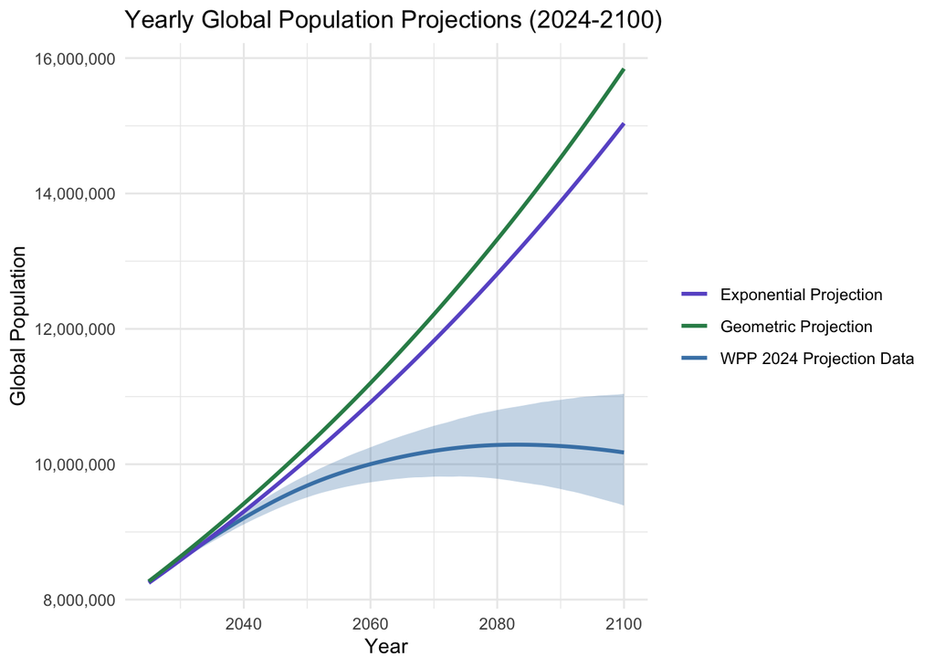

```r
year_sequence <- seq(2025, 2100, by = 1)

# Cubic spline to plot
spline_fit_exp <- spline(output_exp$year, output_exp$pop, xout = year_sequence)
spline_fit_geom <- spline(output_geom$year, output_geom$Projected_Population, xout = year_sequence)

# Plotting the population projections
ggplot() + geom_line(aes(x = popproj1dt_world$year, y = popproj1dt_world$pop, color = "WPP 2024 Projection Data"),
    size = 1) + geom_ribbon(aes(x = popproj1dt_world$year, ymin = popproj1dt_world$pop_80l,
    ymax = popproj1dt_world$pop_80u), fill = "steelblue", alpha = 0.3) + geom_line(aes(x = spline_fit_exp$x,
    y = spline_fit_exp$y, color = "Exponential Projection"), linewidth = 1) + geom_line(aes(x = spline_fit_geom$x,
    y = spline_fit_geom$y, color = "Geometric Projection"), linewidth = 1) + labs(title = "Yearly Global Population Projections (2024-2100)",
    x = "Year", y = "Global Population") + scale_color_manual(values = c(`WPP 2024 Projection Data` = "steelblue",
    `Exponential Projection` = "slateblue", `Geometric Projection` = "seagreen")) +
    scale_y_continuous(labels = label_comma()) + theme_minimal() + theme(legend.title = element_blank())
```

**(f)** **5 points** *Comment on the geometric and exponential growth assumptions compared to the more sophisticated model underlying the WPP 2024 projections, which are Bayesian hierarchical models of life expectancy, the total fertility rate, and net migration that incorporate demographic theory.*

The first two, the geometric and exponential growth models, are relatively simple. For example, they do not account for migration or other real-life determinants of population size. The WPP 2024 projections are much more sophisticated because they include many more factors into their forecasts.

According to the textbook and external presentation slides, the first two methods are sufficient for preliminary forecasting, such as with data lacking substantial information. They can be implemented easily and quickly. However, these methods are oversimplified.

# Problem 3: Child mortality - 25 points

*We will use the [Demographic & Health Surveys](https://dhsprogram.com) model births record dataset, `ZZBR62FL.DAT` for this problem. [Download full model datasets here.](https://dhsprogram.com/data/Download-Model-Datasets.cfm?flag=1)[See the Recode manual here.](https://dhsprogram.com/publications/publication-dhsg4-dhs-questionnaires-and-manuals.cfm)*

*Variables:*

- **caseid** - unique identifier of the child’s mother
- **bidx** - unique identifier of children for a given **caseid**
- **v006** - interview month
- **v007** - interview year
- **b1** - birth month
- **b2** - birth year
- **b5** - indicator child was alive at time of interview
- **b7** - child age in months at death

**(a)** **5 points** *How many person-months does the 1981 sample birth cohort contribute to the calendar years 1981, 1982, and 1983. Show your calculation code in an `R` chunk, and present your answers in a table. State any assumptions you make in calculating your answers.*

I assumed that a child contributes a person-month for the month they were born; for example, a child born in 02/1981 and died in 09/1981 contributes 8 person-months rather than 7.

if a child has NA in column b7, then they have contributed an amount person-months equivalent to the amount of months between their start_month and December for 1981, and 12 person-months each for 1982 and 1983, because they survived to the end of all 3 years.

If the value in column b7 for a child is between 0-12, they contributed that amount of person-months for 1981, but 0 for 1982 and 0 for 1983. This is because this is their age in months when they died, and in one year, a child in the 1981 cohort can be a maximum of 12 months old.

If the value in column b7 for a child is between 12-24, they contributed 12 person-months for 1981, and contributed the difference between the value in column b7 minus 12 for 1982, and 0 for 1983.

```r
# Filtering the data for only the 1981 cohort and adding four new columns
# start_month and end_month indicate the month of the year they were born/died
# start_year/end_year do the same.
births_1981_pm <- births %>%
    filter(b2 == 1981) %>%
    mutate(start_month = b1, end_month_1981 = ifelse(is.na(b7), 12, pmin(12, start_month +
        b7 - 1)), months_1981 = ifelse(is.na(b7), 12 - start_month + 1, pmax(0, end_month_1981 -
        start_month + 1)), months_1982 = ifelse(is.na(b7), 12, ifelse(b7 > 12, pmin(12,
        b7 - 12), 0)), months_1983 = ifelse(is.na(b7), 12, ifelse(b7 > 24, pmin(12,
        b7 - 24), 0)))
# check the start and end months/years head(births_1981_pm) make the
# person-months table for each year
person_months <- births_1981_pm %>%
    summarize(`1981` = sum(months_1981, na.rm = TRUE), `1982` = sum(months_1982,
        na.rm = TRUE), `1983` = sum(months_1983, na.rm = TRUE)) %>%
    pivot_longer(cols = everything(), names_to = "year", values_to = "person_months")

kable(person_months, col.names = c("Year", "Person Months"), caption = "Estimated Person-MonthsFrom the 1981 Sample \nBirth Cohort in 1981, 1982, and 1983") %>%
    kable_styling(font_size = 15)
```

Estimated Person-MonthsFrom the 1981 Sample Birth Cohort in 1981, 1982, and 1983

| Year | Person Months |
| --- | --- |
| 1981 | 118 |
| 1982 | 156 |
| 1983 | 156 |

**(b)** **5 points** *What is the sample cohort infant mortality rate (IMR) for the birth cohort born in 1982? Show your calculation code in an `R` chunk.*

*In the same `R` chunk, **(c)5 points** What is the sample period infant mortality rate (IMR) for the year 1982?*

I am assuming infant deaths refer to deaths of children under the age of 12 mo.

Also, I’m assuming sample cohort $IMR = \frac{\text{Number of deaths of children under 1 year of age*1000}}{\text{Total Live Births}}$, whereas I’m assuming sample period $IMR_{1982} = \frac{\text{Number of deaths of children under 1 year of age in 1982*1000}}{\text{Total Live Births in 1982}}$.

That is, in the sample cohort IMR, I am focusing on children born in 1982, but they could die in either 1982 or 1983, just until they turn 12mo.

However, for sample period IMR, I am focusing on the deaths of all infants (0-12mo.) that died in 1982. They could have been born as early as 1981.

```r
# COHORT IMR for 1982
births_1982_imr = births %>%
    filter(b2 == 1982)  # Filter for 1982 birth cohort

# Total live births in the 1982 cohort
total_live_births_cohort <- nrow(births_1982_imr)

# Infant deaths in the 1982 cohort (under 1 year, b7 < 12 months)
infant_deaths_1982 = births_1982_imr %>%
    filter(!is.na(b7), b7 < 12) %>%
    nrow()

# Cohort IMR for 1982
cohort_imr_1982 = (infant_deaths_1982/total_live_births_cohort) * 1000

# PERIOD IMR for 1982 Total live births in 1982
live_births_1982 = births %>%
    filter(b2 == 1982) %>%
    nrow()

# Infant deaths that occurred in 1982 (b7 < 12 months AND death year = 1982)
infant_deaths_period = births %>%
    filter(!is.na(b7), b7 < 12, b2 + (b1 + b7)%/%12 == 1982) %>%
    nrow()

# Period IMR for 1982
period_imr_1982 = (infant_deaths_period/live_births_1982) * 1000

# Results
results = data.frame(Metric = c("Cohort IMR for 1982 per 1,000 live births", "Period IMR for 1982 per 1,000 live births"),
    IMR = c(cohort_imr_1982, period_imr_1982))

# print(results, row.names = FALSE)
kable(results, digits = 2, caption = "Period vs. Cohort Infant Mortality Rate (IMR) for 1982 per 1,000 live births") %>%
    kable_styling(font_size = 15)
```

Period vs. Cohort Infant Mortality Rate (IMR) for 1982 per 1,000 live births

| Metric | IMR |
| --- | --- |
| Cohort IMR for 1982 per 1,000 live births | 127.27 |
| Period IMR for 1982 per 1,000 live births | 163.64 |

**(d)** **10 points** *Calculate cohort age-specific mortality rates for each of month the first 12 months of life for the birth cohort born in 2012. Show your calculation code in an `R` chunk. Present your estimates in a plot with age on the* $x$*-axis. State clearly any assumptions you make in your calculation.*

In making the mortality rate calculation, I am assuming the deaths/total births is constant for each month. That is, I’m not calculating the fraction of deaths out of surviving infants, but rather the fraction of deaths in that month out of total live births for that cohort.

```r
births_2012_age_specific_mr <- births %>%
  filter(b2 == 2012) %>% # Filter for 1982 birth cohort
  filter(!is.na(b7), b7 <= 12)

# head(births_2012_age_specific_mr)
```

```r
#gets the total number of live births for infants born in 2012
total_2012_b = nrow(births_2012_age_specific_mr)

age_specific_mortality = births_2012_age_specific_mr %>%
  group_by(b7) %>% # Group by age at death (b7)
  summarise(deaths = n()) %>%
  mutate(mortality_rate_per1000 = (deaths / total_2012_b) * 1000)
# age_specific_mortality

all_months = data.frame(b7 = 0:12)
age_specific_mortality = all_months %>%
  left_join(age_specific_mortality, by = "b7") %>%
  mutate(
    deaths = ifelse(is.na(deaths), 0, deaths),
    mortality_rate_per1000 = ifelse(is.na(mortality_rate_per1000), 0, mortality_rate_per1000)
  )
# all_months
```

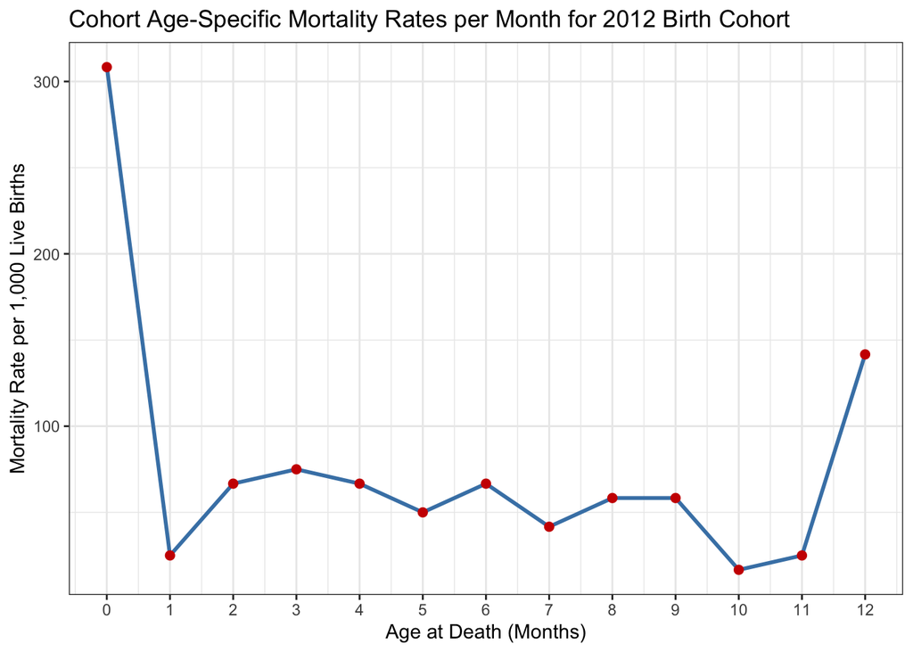

```r
ggplot(age_specific_mortality, aes(x = b7, y = mortality_rate_per1000)) + geom_line(color = "steelblue",
    linewidth = 1) + geom_point(color = "red3", size = 2) + labs(title = "Cohort Age-Specific Mortality Rates per Month for 2012 Birth Cohort",
    x = "Age at Death (Months)", y = "Mortality Rate per 1,000 Live Births") + scale_x_continuous(breaks = seq(0,
    max(age_specific_mortality$b7, na.rm = TRUE), by = 1)) + theme_bw()
```

# Problem 4: Age standardization - 25 points

*Go to the [Human Mortality Database](https://www.mortality.org/Home/Index) and download the following files for a country of your choice:*

- *Death Rates 5x5*
- *Population 5x1*

**Note:** You will have to register for an account and will immediately receive a confirmation email. Once you confirm your email, you can download the data.

**(a)** **5 points** *For two periods in the datasets, create a two-panel plot containing histograms of the age-specific death rates for males and histograms of the age-specific population (e.g. use two different colors on the same plot for each period).*

I am assuming this means to create a two-panel plot, where one panel has the histogram of age-specific death rates for males, with two periods overlaid (stacked), and another panel has the histogram of the age-specific population for males, with the same two periods as the first panel, overlaid.

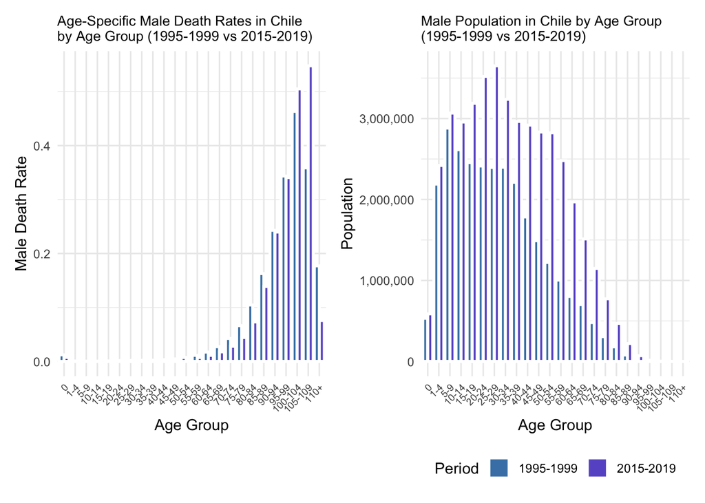

```r
# Plot the histogram of Male Death Rates by Age Group for the two periods
plot1 = ggplot(death_rates_chile_filtered, aes(x = Age, y = Male, fill = Year)) +
  geom_bar(stat = "identity", position = "dodge", color = "white", linewidth = 1) +  # use `linewidth` here
  scale_fill_manual(values = c("steelblue", "slateblue")) +
  ggtitle("Age-Specific Male Death Rates in Chile\nby Age Group (1995-1999 vs 2015-2019)") +
  xlab("Age Group") +
  ylab("Male Death Rate") +
  theme_minimal() +
  theme(axis.text.x = element_text(angle = 45, hjust = 1, size = 7),
        legend.position = "none",
        plot.title = element_text(size = 10))

plot2 = ggplot(age_population_summary, aes(x = Age, y = Total_Male_Population, fill = Period)) +
  geom_bar(stat = "identity", position = "dodge", color = "white", linewidth = 1) +
  scale_fill_manual(values = c("steelblue", "slateblue")) +
  ggtitle("Male Population in Chile by Age Group\n(1995-1999 vs 2015-2019)") +
  xlab("Age Group") +
  ylab("Population") +
  scale_y_continuous(labels = label_comma()) +
  theme_minimal() +
  theme(axis.text.x = element_text(angle = 45, hjust = 1, size = 7),
        legend.position = "bottom",
        plot.title = element_text(size = 10))

# Combine the two plots without any legends
plot1 + plot2 + plot_layout(ncol = 2)
```

It is interesting to see that 20 years after the first period, the death rate is decreased for all male age groups below the age of 100-104. I interpret this to mean that more people are living to old age in the 2010s compared to the 1990s. This is supported by the population distribution in the second graph, where we see an increase in population in all age groups.

Additionally, another interesting moment is the blue spike of population in the 5-9 age category becomes the purple spike in population in the 25-29 category 20 years later. This visualization shows that age cohort growing up.

**(b)** **5 points** *Calculate the crude death rate for each period you selected using the death rates and age-specific population composition. Show your calculation in an `R` chunk and present your answers in a table.*

I am assuming to calculate the CDR for the total population instead of the just males as in the last problem. I am also assuming CDR can be estimated using the following formula: $\text{Crude Death Rate (CDR)} = \frac{\text{Total Number of Deaths}}{\text{Total Population}} \times 1000$

This new function calculates CDR per 1,000 individuals in the total population, per age range. This is different from the next question, which displays a CDR that is an average of all the age ranges’ CDRs in order to compare it to the age-standardized death rate. It also is agnostic to the male/female subsets of the total population, which will be calculated in the next question.

```r
# this is a function to calculate total-population CDR over multiple periods to
# make it more replicable
calculate_total_cdr = function(data) {
    results <- data %>%
        # Total deaths = Total_Population * Death Rate
    mutate(Total_Deaths = Total_Population * Total, Total_CDR = (Total_Deaths/Total_Population) *
        1000) %>%
        # Select relevant columns, total_male_pop and total_female_pop become
        # important in the last few questions.
    select(Age, Year, Total_Population, Total_Male_Population, Total_Female_Population,
        Total_Deaths, Total_CDR, Female, Male)

    # n = Inf allows all columns to be displayed print(results, row.names =
    # FALSE, n = Inf) return(results)
}

results_period1 = calculate_total_cdr(joined_data_period1)
results_period2 = calculate_total_cdr(joined_data_period2)

kable(results_period1 %>%
    mutate(Total_Population = comma(Total_Population), Total_Male_Population = comma(Total_Male_Population),
        Total_Female_Population = comma(Total_Female_Population), Total_Deaths = comma(Total_Deaths)),
    col.names = c("Age", "Year", "Total Population", "Total Male Population", "Total Female Population",
        "Total Deaths", "Total CDR", "Female", "Male"), caption = "Total Population Crude Death Rate by Age Group (1995-1999)") %>%
    kable_styling(font_size = 15) %>%
    scroll_box(width = "900px", height = "500px")
```

Total Population Crude Death Rate by Age Group (1995-1999)

| Age | Year | Total Population | Total Male Population | Total Female Population | Total Deaths | Total CDR | Female | Male |
| --- | --- | --- | --- | --- | --- | --- | --- | --- |
| 0 | 1995-1999 | 1,041,784 | 532,360 | 509,424 | 11,564.84 | 11.101 | 0.010036 | 0.012121 |
| 1-4 | 1995-1999 | 4,289,831 | 2,190,078 | 2,099,753 | 2,329.38 | 0.543 | 0.000504 | 0.000580 |
| 5-9 | 1995-1999 | 5,651,097 | 2,882,101 | 2,768,995 | 1,401.47 | 0.248 | 0.000204 | 0.000290 |
| 10-14 | 1995-1999 | 5,139,205 | 2,615,374 | 2,523,832 | 1,361.89 | 0.265 | 0.000211 | 0.000317 |
| 15-19 | 1995-1999 | 4,851,352 | 2,456,102 | 2,395,250 | 2,799.23 | 0.577 | 0.000330 | 0.000818 |
| 20-24 | 1995-1999 | 4,811,305 | 2,414,234 | 2,397,071 | 4,445.65 | 0.924 | 0.000386 | 0.001458 |
| 25-29 | 1995-1999 | 4,835,290 | 2,395,490 | 2,439,800 | 5,067.38 | 1.048 | 0.000447 | 0.001659 |
| 30-34 | 1995-1999 | 4,888,443 | 2,398,393 | 2,490,050 | 6,174.10 | 1.263 | 0.000622 | 0.001928 |
| 35-39 | 1995-1999 | 4,519,599 | 2,212,426 | 2,307,172 | 7,068.65 | 1.564 | 0.000913 | 0.002242 |
| 40-44 | 1995-1999 | 3,661,740 | 1,784,685 | 1,877,055 | 8,411.02 | 2.297 | 0.001441 | 0.003198 |
| 45-49 | 1995-1999 | 3,060,026 | 1,490,596 | 1,569,429 | 10,627.47 | 3.473 | 0.002389 | 0.004614 |
| 50-54 | 1995-1999 | 2,521,800 | 1,222,232 | 1,299,568 | 13,950.60 | 5.532 | 0.003920 | 0.007246 |
| 55-59 | 1995-1999 | 2,105,741 | 1,004,717 | 1,101,024 | 17,837.73 | 8.471 | 0.005962 | 0.011216 |
| 60-64 | 1995-1999 | 1,714,963 | 802,438 | 912,524 | 22,447.15 | 13.089 | 0.009422 | 0.017257 |
| 65-69 | 1995-1999 | 1,538,547 | 701,222 | 837,325 | 31,786.38 | 20.660 | 0.015174 | 0.027191 |
| 70-74 | 1995-1999 | 1,082,954 | 479,608 | 603,346 | 35,614.02 | 32.886 | 0.025252 | 0.042505 |
| 75-79 | 1995-1999 | 738,728 | 305,920 | 432,807 | 38,642.11 | 52.309 | 0.042388 | 0.066292 |
| 80-84 | 1995-1999 | 489,105 | 180,280 | 308,825 | 40,463.15 | 82.729 | 0.069998 | 0.104559 |
| 85-89 | 1995-1999 | 239,641 | 79,310 | 160,330 | 32,007.85 | 133.566 | 0.119142 | 0.162769 |
| 90-94 | 1995-1999 | 79,601 | 22,990 | 56,611 | 16,561.94 | 208.063 | 0.193946 | 0.242960 |
| 95-99 | 1995-1999 | 16,816 | 4,162 | 12,654 | 5,068.27 | 301.398 | 0.287555 | 0.343651 |
| 100-104 | 1995-1999 | 1,975 | 401 | 1,574 | 809.51 | 409.795 | 0.396111 | 0.463434 |
| 105-109 | 1995-1999 | 213 | 56 | 157 | 81.52 | 381.863 | 0.389919 | 0.358740 |
| 110+ | 1995-1999 | 31 | 9 | 22 | 6.33 | 204.125 | 0.215067 | 0.177096 |

```r
kable(results_period2 %>%
    mutate(Total_Population = comma(Total_Population), Total_Male_Population = comma(Total_Male_Population),
        Total_Female_Population = comma(Total_Female_Population), Total_Deaths = comma(Total_Deaths)),
    col.names = c("Age", "Year", "Total Population", "Total Male Population", "Total Female Population",
        "Total Deaths", "Total CDR", "Female", "Male"), caption = "Total Population Crude Death Rate by Age Group (2015-2019)") %>%
    kable_styling(font_size = 15) %>%
    scroll_box(width = "900px", height = "500px")
```

Total Population Crude Death Rate by Age Group (2015-2019)

| Age | Year | Total Population | Total Male Population | Total Female Population | Total Deaths | Total CDR | Female | Male |
| --- | --- | --- | --- | --- | --- | --- | --- | --- |
| 0 | 2015-2019 | 1,152,456 | 587,202 | 565,254 | 7,823 | 6.788 | 0.006191 | 0.007364 |
| 1-4 | 2015-2019 | 4,748,587 | 2,420,353 | 2,328,235 | 1,249 | 0.263 | 0.000246 | 0.000280 |
| 5-9 | 2015-2019 | 6,008,931 | 3,067,663 | 2,941,268 | 799 | 0.133 | 0.000130 | 0.000135 |
| 10-14 | 2015-2019 | 5,789,979 | 2,957,117 | 2,832,862 | 938 | 0.162 | 0.000152 | 0.000171 |
| 15-19 | 2015-2019 | 6,248,105 | 3,188,502 | 3,059,603 | 2,793 | 0.447 | 0.000269 | 0.000618 |
| 20-24 | 2015-2019 | 6,951,956 | 3,520,244 | 3,431,712 | 4,428 | 0.637 | 0.000331 | 0.000935 |
| 25-29 | 2015-2019 | 7,249,986 | 3,651,725 | 3,598,260 | 5,466 | 0.754 | 0.000369 | 0.001134 |
| 30-34 | 2015-2019 | 6,487,317 | 3,237,646 | 3,249,671 | 5,826 | 0.898 | 0.000484 | 0.001313 |
| 35-39 | 2015-2019 | 6,006,599 | 2,963,896 | 3,042,702 | 7,070 | 1.177 | 0.000724 | 0.001641 |
| 40-44 | 2015-2019 | 5,963,425 | 2,919,060 | 3,044,365 | 9,780 | 1.640 | 0.001087 | 0.002216 |
| 45-49 | 2015-2019 | 5,843,072 | 2,833,828 | 3,009,244 | 13,953 | 2.388 | 0.001653 | 0.003167 |
| 50-54 | 2015-2019 | 5,871,017 | 2,823,649 | 3,047,368 | 21,306 | 3.629 | 0.002523 | 0.004821 |
| 55-59 | 2015-2019 | 5,199,698 | 2,480,507 | 2,719,191 | 28,624 | 5.505 | 0.003972 | 0.007186 |
| 60-64 | 2015-2019 | 4,172,372 | 1,970,439 | 2,201,932 | 35,970 | 8.621 | 0.006306 | 0.011207 |
| 65-69 | 2015-2019 | 3,258,449 | 1,513,439 | 1,745,010 | 44,637 | 13.699 | 0.010280 | 0.017643 |
| 70-74 | 2015-2019 | 2,544,823 | 1,148,223 | 1,396,600 | 55,414 | 21.775 | 0.016643 | 0.028009 |
| 75-79 | 2015-2019 | 1,806,723 | 773,405 | 1,033,318 | 62,766 | 34.740 | 0.027578 | 0.044282 |
| 80-84 | 2015-2019 | 1,183,331 | 469,583 | 713,748 | 69,391 | 58.640 | 0.049043 | 0.073191 |
| 85-89 | 2015-2019 | 611,620 | 220,685 | 390,935 | 71,879 | 117.522 | 0.105494 | 0.138792 |
| 90-94 | 2015-2019 | 232,084 | 71,002 | 161,082 | 48,426 | 208.659 | 0.194828 | 0.239835 |
| 95-99 | 2015-2019 | 62,620 | 15,229 | 47,391 | 19,092 | 304.883 | 0.293230 | 0.340705 |
| 100-104 | 2015-2019 | 9,711 | 1,635 | 8,076 | 4,173 | 429.718 | 0.414245 | 0.505142 |
| 105-109 | 2015-2019 | 803 | 90 | 713 | 380 | 473.503 | 0.464305 | 0.547965 |
| 110+ | 2015-2019 | 85 | 25 | 59 | 21 | 252.239 | 0.324107 | 0.075786 |

**(c)** **5 points** *Using age standardization to the most recent period you selected, compare the crude death rates and age-standardized death rates for males between the two periods. Comment on the comparison in text.*

I am assuming the direct age standardization can be accomplished by using a description of the process in this PDF: [Chapter 7: Age standardization - World Health Organization](https://publications.iarc.who.int/_publications/media/download/3753/609d0d7711047dd76d7f3dbaa25d7f041fcd013e.pdf) and this study guide: [Standardization (#4)](https://quizlet.com/446047357/standardization-4-flash-cards/).

I am also assuming the 2015-2019 period is the standard population, and that this CDR is the adjusted rate per 1,000 people. I have tried to adapt my function from the previous problem to use in this problem, with the goal being that I can use just this one in the future.

```r
male_cdr_and_asdr = function(data1, data2) {
  # Calculate CDR for each period
  calculate_cdr = function(data) {
    results = data %>%
      mutate(
        Total_Male_Deaths = Total_Population * Male,  # Total deaths = Total_Population * Death Rate
        Male_CDR = (Total_Male_Deaths / Total_Population) * 1000  # CDR formula
      ) %>%
      select(Age, Year, Total_Population, Total_Male_Deaths, Male_CDR, Male)

    # # Print results for this period
    # print(results, n = Inf)
    # return(results)
  }

  # Calculate CDR for each period
  results1 = calculate_cdr(data1)
  results2 = calculate_cdr(data2)

  # Age-standardized deaths for the first period, aligned with the second period's population
  age_standardized_deaths1 = sum(results1$Male * results2$Total_Population)
  # Age-standardized deaths for the second period
  age_standardized_deaths2 = sum(results2$Male * results2$Total_Population)

  # Total population of the second period for age standardization
  total_population_period2 = sum(results2$Total_Population)

  # Calculate ASDR
  asdr1 = (age_standardized_deaths1 / total_population_period2) * 1000
  asdr2 = (age_standardized_deaths2 / total_population_period2) * 1000

  # Create comparison results
  comparison = data.frame(
    Period = c("1995-1999", "2015-2019"),
    Crude_Death_Rate = c(mean(results1$Male_CDR), mean(results2$Male_CDR)),  # Mean CDR for each period
    Age_Standardized_Death_Rate = c(asdr1, asdr2)
  )

  # Print the comparison results
  # print(comparison, row.names = FALSE)
}

# Apply the function
output = male_cdr_and_asdr(joined_data_period1, joined_data_period2)

kable(output,
      col.names = c("Period", "Male Crude Death Rate", "Male Age-Standardized Death Rate"),
      digits = 2,
      caption = "Male Population Crude Death Rate (1995-1999 to 2015-2019)") %>%
  kable_styling(font_size = 15)
```

Male Population Crude Death Rate (1995-1999 to 2015-2019)

| Period | Male Crude Death Rate | Male Age-Standardized Death Rate |
| --- | --- | --- |
| 1995-1999 | 85.59 | 10.47 |
| 2015-2019 | 85.56 | 7.50 |

While crude rates are a quick and efficient metric that displays a summary of the population’s death rate, age-standardized death rates are more complex. An age-standardized death rate is an example of an adjusted rate, something that changes or “adjusts” the crude rate to remove a confounding effect. This makes adjusted rates more robust to other factors which makes them ideal for comparing metrics.

**(d)** **10 points** *Calculate the crude death rate for males and females from age-specific death rates and the age-specific population composition in the most recent period available. Then use age standardization to the male age distribution to calculate comparable crude death rates. Show your calculation in an `R` chunk and present your answers in a table. Comment on the comparison between the two sex-specific crude death rates and the set of sex-specific age-standardized death rates.*

I assume this question to mean the following:

1. calculate the aggregate crude death rate for males and females for 1995-1999 and 2015-2019 using the more recent (2015-2019) age-specific death rates and the age-specific population composition.
2. Standardize the female population using the male population as a reference to get the age-standardized adjusted female and male death rates.

This means the following output will be like in the previous problem, where any crude death rates and age-standardized crude death rates will be averaged across all age-groups, rather than having one CDR and ASDR per age group.

```r
male_female_cdr_and_asdr = function(data1, data2) {
  # Calculate CDR for each period (for both males and females)
  calculate_cdr = function(data) {
    results = data %>%
      mutate(
        Total_Male_Deaths = Total_Population * Male,  # Total Male deaths
        Total_Female_Deaths = Total_Population * Female,  # Total Female deaths
        Male_CDR = (Total_Male_Deaths / Total_Population) * 1000,  # CDR for Male
        Female_CDR = (Total_Female_Deaths / Total_Population) * 1000  # CDR for Female
      ) %>%
      select(Age, Year, Total_Population, Total_Male_Deaths, Total_Female_Deaths, Male_CDR, Female_CDR, Male, Female)

    return(results)
  }

  # Calculate CDR for both periods
  results1 = calculate_cdr(data1)
  results2 = calculate_cdr(data2)

  # Age-standardized deaths for males in both periods
  age_standardized_deaths1_male = sum(results1$Male * results2$Total_Population)
  age_standardized_deaths2_male = sum(results2$Male * results2$Total_Population)

  # Age-standardized deaths for females in both periods
  age_standardized_deaths1_female = sum(results1$Female * results2$Total_Population)
  age_standardized_deaths2_female = sum(results2$Female * results2$Total_Population)

  # Total population of the second period for age standardization
  total_population_period2 = sum(results2$Total_Population)

  # Calculate ASDR for males and females
  asdr1_male = (age_standardized_deaths1_male / total_population_period2) * 1000
  asdr2_male = (age_standardized_deaths2_male / total_population_period2) * 1000
  asdr1_female = (age_standardized_deaths1_female / total_population_period2) * 1000
  asdr2_female = (age_standardized_deaths2_female / total_population_period2) * 1000

  # Create a comparison table
  comparison = data.frame(
    Period = c("1995-1999", "2015-2019"),
    Male_Crude_Death_Rate = c(mean(results1$Male_CDR), mean(results2$Male_CDR)),
    Female_Crude_Death_Rate = c(mean(results1$Female_CDR), mean(results2$Female_CDR)),
    Male_Age_Standardized_Death_Rate = c(asdr1_male, asdr2_male),
    Female_Age_Standardized_Death_Rate = c(asdr1_female, asdr2_female)
  )

  # Print the comparison results
  # print(comparison, row.names = FALSE)
}

# Apply the function
output = male_female_cdr_and_asdr(joined_data_period1, joined_data_period2)

kable(output,
      col.names = c("Period", "Male Crude Death Rate", "Female Crude Death Rate", "Male Age-Standardized Death Rate", "Female Age-Standardized Death Rate"),
      digits = 2,
      caption = "Assigned Gender at Birth Subset Unstandardized vs. Age-Standardized Crude Death Rates (1995-1999 to 2015-2019)") %>%
  kable_styling(font_size = 15)
```

Assigned Gender at Birth Subset Unstandardized vs. Age-Standardized Crude Death Rates (1995-1999 to 2015-2019)

| Period | Male Crude Death Rate | Female Crude Death Rate | Male Age-Standardized Death Rate | Female Age-Standardized Death Rate |
| --- | --- | --- | --- | --- |
| 1995-1999 | 85.59 | 74.64 | 10.47 | 6.44 |
| 2015-2019 | 85.56 | 80.17 | 7.50 | 4.79 |

In both sets of rates, males have higher death rates regardless of adjustment, which may be indicative of social, economic, or health factors disproportionately affecting males vs. females. When comparing the un-adjusted rates to the adjusted rates, the un-adjusted rates are higher in comparison for both males and females, which might lead us to believe that while the total population is aging (more people live to old age), the likelihood of dying drops. This is interesting because it is consistent with the visualizations of Chile’s population distribution and death rates earlier in the homework.